# Analysis of the usage rate of the online-to-offline (O2O) pickup order feature on a certain e-commerce website

A certain online e-commerce website has launched the "online-to-offline pickup order" feature. We aim to understand the current usage status and influencing factors of this feature, as well as identify a key list of customers that could help increase the usage rate of this feature.

```python
import pandas as pd
import os
import matplotlib.pyplot as plt
import numpy as np

# Data source path
data_path = './Data June'
path = os.path.abspath(data_path)
df = pd.DataFrame()
```

```python
# Folder traversal and data splicing, output df
for file_ in os.listdir(path):
    if file_ != '.DS_Store':
        file_df = pd.read_csv(path + '/' + file_, encoding='GB18030', parse_dates=[0], infer_datetime_format=True)
        df = pd.concat([df, file_df], ignore_index=True)
```

```python
df.head()
```

|  | Customer | Warehouse | Order Time | Product name | Order weight | Order type | Outbound plan number |
| --- | --- | --- | --- | --- | --- | --- | --- |
| 0 | Company 9 | Warehouse_A | 2020-06-01 00:16:21 373 | Coiled rebar | 2.410 | 1 | OS2006010002 |
| 1 | Company 9 | Warehouse_A | 2020-06-01 00:18:20 828 | Coiled rebar | 2.406 | 1 | OS2006010003 |
| 2 | Company 17 | Warehouse_A | 2020-06-01 00:38:47 186 | Hot coil | 22.360 | 3 | OS2006010006 |
| 3 | Company 1 | Warehouse_A | 2020-06-01 01:28:35 199 | Rebar | 1.944 | 1 | OS2006010013 |
| 4 | Company 3 | Warehouse_A | 2020-06-01 01:32:31 091 | Low-alloy medium plate | 4.446 | 1 | OS2006010014 |

```python
df.info()
```

```
<class 'pandas.core.frame.DataFrame'>
RangeIndex: 18386 entries, 0 to 18385
Data columns (total 7 columns):
 #   Column                Non-Null Count  Dtype
---  ------                --------------  -----
 0   Customer              18386 non-null  object
 1   Warehouse             18386 non-null  object
 2   Order Time            18386 non-null  object
 3   Product name          18386 non-null  object
 4   Order weight          18386 non-null  float64
 5   Order type            18386 non-null  int64
 6   Outbound plan number  18386 non-null  object
dtypes: float64(1), int64(1), object(5)
memory usage: 1005.6+ KB
```

## Clean and organize data according to business rules.

```python
# Filter out data that meets the assessment rules
df = df[df['Warehouse'].isin (['Warehouse_A','Warehouse_B'])]
df = df.drop_duplicates(['Outbound plan number'])

# delete the useless characters
df['Order Time'] = df['Order Time'].apply(lambda x: x[:19])
# transform the data type
df['Order Time'] = pd.to_datetime(df['Order Time'])

# the business rule mark the Order type 1,4,5,6 as online way, others is offline way.
df['Order type'].replace({1:'online', 2:'offline', 3:'offline', 4:'online', 5:'online', 6:'online'}, inplace = True)
```

## Explore the proportion of Online Orders to Total Orders

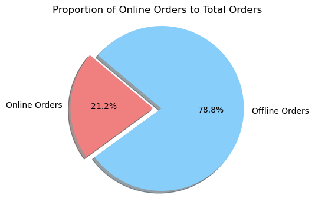

```python
# Total orders vs. Online orders Pie Chart
total_orders = df['Outbound plan number'].count()
online_orders = df[df['Order type'] == 'online']['Outbound plan number'].count()
offline_orders = total_orders - online_orders

# Data for pie chart
labels = 'Online Orders', 'Offline Orders'
sizes = [online_orders, offline_orders]
colors = ['lightcoral', 'lightskyblue']
explode = (0.1, 0)  # explode 1st slice

# Plot
plt.figure(figsize=(4, 4))
plt.pie(sizes, explode=explode, labels=labels, colors=colors, autopct='%1.1f%%', shadow=True, startangle=140)
plt.title('Proportion of Online Orders to Total Orders')
plt.axis('equal')
plt.show()
```

## Explore the relationship between product categories and online ordering rates.

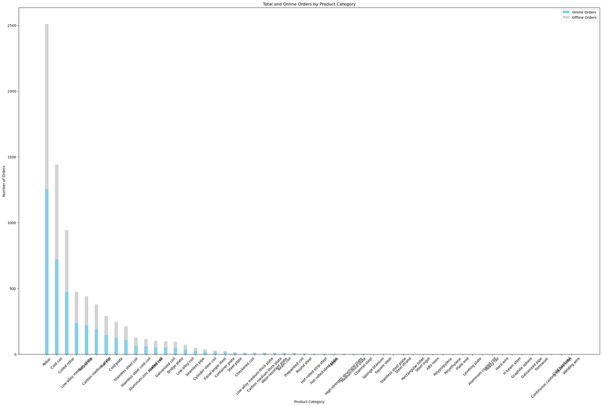

```python
df_product_analyst = df

df_product_analyst['Online Order'] = df_product_analyst['Order type'].apply(lambda x: 1 if x == 'online' else 0)
df_product_analyst['Offline Order'] = df_product_analyst['Order type'].apply(lambda x: 0 if x == 'offline' else 1)

# Group by product category, calculate the total number of orders, the number of online orders, and the number of offline orders.
grouped = df_product_analyst.groupby('Product name').agg(
    Total_Orders=pd.NamedAgg(column='Order type', aggfunc='count'),
    Online_Orders=pd.NamedAgg(column='Online Order', aggfunc='sum'),
    Offline_Orders=pd.NamedAgg(column='Offline Order', aggfunc='sum')
).reset_index()
grouped.sort_values(by='Offline_Orders', ascending=False, inplace=True)

fig, ax = plt.subplots(figsize=(30, 18))
ind = np.arange(len(grouped))
width = 0.35

p1 = ax.bar(ind, grouped['Online_Orders'], width, label='Online Orders', color='skyblue')
p2 = ax.bar(ind, grouped['Offline_Orders'], width, bottom=grouped['Online_Orders'], label='Offline Orders', color='lightgrey')

ax.set_title('Total and Online Orders by Product Category')
ax.set_xlabel('Product Category')
ax.set_ylabel('Number of Orders')
ax.set_xticks(ind)
ax.set_xticklabels(grouped['Product name'], rotation=45)
ax.legend()

plt.show()
```

We can see the main goods of the relevant warehouse and the proportion of order methods for their pick-up orders. However, it appears that the category of goods does not affect the customers' ordering methods.

## Explore the relationship between order timing and online ordering rates.

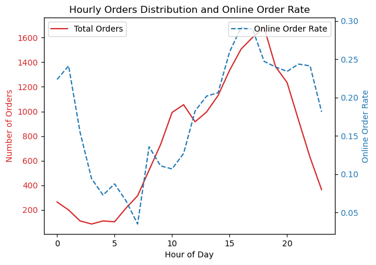

```python
df_line_chart = df.set_index('Order Time')

df_line_chart['hour'] = df_line_chart.index.hour

hourly_data = df_line_chart.groupby('hour').agg(
    Total_Orders=('Order type', 'count'),
    Online_Orders=('Online Order', 'sum')
)


hourly_data['Online Order Rate'] = hourly_data['Online_Orders'] / hourly_data['Total_Orders']


fig, ax1 = plt.subplots()


color = 'tab:red'
ax1.set_xlabel('Hour of Day')
ax1.set_ylabel('Number of Orders', color=color)
ax1.plot(hourly_data.index, hourly_data['Total_Orders'], color=color, label='Total Orders')
ax1.tick_params(axis='y', labelcolor=color)


ax2 = ax1.twinx()
color = 'tab:blue'
ax2.set_ylabel('Online Order Rate', color=color)
ax2.plot(hourly_data.index, hourly_data['Online Order Rate'], color=color, label='Online Order Rate', linestyle='--')
ax2.tick_params(axis='y', labelcolor=color)


ax1.legend(loc='upper left')
ax2.legend(loc='upper right')

plt.title('Hourly Orders Distribution and Online Order Rate')

plt.show()
```

## Explore the order situation of key customers

```python
df_grouped = df.groupby('Customer')['Order type'].agg(
    order_amount='count',
    online_orders_amount=lambda x: (x == 'online').sum()
).reset_index()

df_grouped['offline_orders_amount'] = df_grouped['order_amount'] - df_grouped['online_orders_amount']
df_grouped['online_rate'] = df_grouped['online_orders_amount'] / df_grouped['order_amount']


df_grouped.sort_values(by='order_amount', ascending=False, inplace=True)


df_grouped['online_rate'] = df_grouped['online_rate'].apply(lambda x: f'{x:.2%}')

df_grouped.reset_index(drop=True, inplace=True)
```

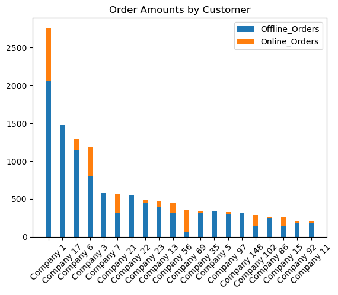

```python
# Bar analyst

data_bar = df_grouped.head(20)

fig, ax = plt.subplots()

# Locations for the groups
ind = np.arange(len(data_bar))
width = 0.35

p1 = ax.bar(ind, data_bar['offline_orders_amount'], width, label='Offline_Orders')
p2 = ax.bar(ind, data_bar['online_orders_amount'], width, bottom=data_bar['offline_orders_amount'], label='Online_Orders')

ax.set_title('Order Amounts by Customer')
ax.set_xticks(ind)
ax.set_xticklabels(data_bar['Customer'])
ax.legend()

plt.xticks(rotation=45)
plt.show()
```

[figure not shown]

```python
# scatter_plot

df_scatter_plot = df_grouped
plt.figure(figsize=(10, 6))
plt.scatter(df_scatter_plot['order_amount'], df_scatter_plot['online_orders_amount'], color='blue', alpha=0.5)
plt.title('Relationship between Total Orders and Online Orders')
plt.xlabel('Total Order Amount')
plt.ylabel('Online Orders Amount')
for i in range(len(df_scatter_plot)):
    plt.annotate(df_scatter_plot.index[i], (df_scatter_plot.iloc[i]['order_amount'], df_scatter_plot.iloc[i]['online_orders_amount']))
plt.grid(True)
plt.show()
```

From this, we can understand that enhancing the online ordering rate of key customers is crucial to improving the overall usage rate of the feature. Here, we need to classify the difficulty of persuading customers based on their usage of the feature, to assign different departments to undertake offline visits, marketing activities, etc., encouraging customers to be more willing to use this feature and provide feedback.

```python
df_ctm = df_grouped

df_ctm['online_rate'] = df_ctm['online_rate'].str.rstrip('%').astype('float') / 100.0

# Those who have never placed an order online are the most difficult customers.
ctm_hard = df_ctm[df_ctm['online_orders_amount']==0]

# Customers who have placed orders online and whose online order rate is greater than 10% are considered easy customers
ctm_easy = df_ctm[(df_ctm['online_orders_amount']>0) & (df_ctm['online_rate']>=0.1)]

ctm_middle = df_ctm[(df_ctm['online_orders_amount']>0) & (df_ctm['online_rate']<0.1)]
```

```python
ctm_hard
```

|  | Customer | order_amount | online_orders_amount | offline_orders_amount | online_rate |
| --- | --- | --- | --- | --- | --- |
| 1 | Company 17 | 1472 | 0 | 1472 | 0.0 |
| 4 | Company 7 | 575 | 0 | 575 | 0.0 |
| 6 | Company 22 | 549 | 0 | 549 | 0.0 |
| 12 | Company 5 | 336 | 0 | 336 | 0.0 |
| 14 | Company 148 | 313 | 0 | 313 | 0.0 |
| ... | ... | ... | ... | ... | ... |
| 325 | Company 370 | 1 | 0 | 1 | 0.0 |
| 326 | Company 244 | 1 | 0 | 1 | 0.0 |
| 327 | Company 247 | 1 | 0 | 1 | 0.0 |
| 331 | Company 252 | 1 | 0 | 1 | 0.0 |
| 335 | Company 272 | 1 | 0 | 1 | 0.0 |

160 rows × 5 columns

```python
ctm_middle
```

|  | Customer | order_amount | online_orders_amount | offline_orders_amount | online_rate |
| --- | --- | --- | --- | --- | --- |
| 7 | Company 23 | 486 | 33 | 453 | 0.0679 |
| 11 | Company 35 | 341 | 30 | 311 | 0.0880 |
| 13 | Company 97 | 322 | 30 | 292 | 0.0932 |
| 16 | Company 86 | 257 | 11 | 246 | 0.0428 |
| 24 | Company 43 | 178 | 13 | 165 | 0.0730 |
| 27 | Company 115 | 133 | 2 | 131 | 0.0150 |
| 38 | Company 123 | 80 | 3 | 77 | 0.0375 |
| 51 | Company 350 | 47 | 3 | 44 | 0.0638 |
| 61 | Company 108 | 37 | 2 | 35 | 0.0541 |
| 69 | Company 36 | 33 | 1 | 32 | 0.0303 |
| 93 | Company 48 | 19 | 1 | 18 | 0.0526 |
| 94 | Company 128 | 19 | 1 | 18 | 0.0526 |
| 98 | Company 31 | 18 | 1 | 17 | 0.0556 |
| 109 | Company 40 | 16 | 1 | 15 | 0.0625 |
| 118 | Company 70 | 13 | 1 | 12 | 0.0769 |

```python
ctm_easy
```

|  | Customer | order_amount | online_orders_amount | offline_orders_amount | online_rate |
| --- | --- | --- | --- | --- | --- |
| 0 | Company 1 | 2752 | 701 | 2051 | 0.2547 |
| 2 | Company 6 | 1285 | 136 | 1149 | 0.1058 |
| 3 | Company 3 | 1186 | 383 | 803 | 0.3229 |
| 5 | Company 21 | 557 | 238 | 319 | 0.4273 |
| 8 | Company 13 | 469 | 72 | 397 | 0.1535 |
| ... | ... | ... | ... | ... | ... |
| 332 | Company 255 | 1 | 1 | 0 | 1.0000 |
| 333 | Company 263 | 1 | 1 | 0 | 1.0000 |
| 334 | Company 270 | 1 | 1 | 0 | 1.0000 |
| 336 | Company 277 | 1 | 1 | 0 | 1.0000 |
| 337 | 0 | 1 | 1 | 0 | 1.0000 |

163 rows × 5 columns